# Lecture 4

Projects: 1) Identifying Penguin Species and 2) Optical Character Recognition  
Academic Year 1447  
Term 1  
Dr. Jomana Bashatah  
Slides adapted from Casten Lange

## Before we Begin Let Us Do A Thought Experiment

I want to find somebody to spend a Saturday afternoon with and I am looking for somebody most similar to me (nearest neighbor) in terms of:

- Gender (coded as 0 for female, and 1 for male)
- Age (coded in years)
- Outdoor sports interest (coded from 0 (no interest) to 10 (enthusiast))

**(all categories matter the same to me)**

## Let us do the Calculation for a Similarity Score

#### (average absolute differences)

Sake of argument: I am male (**1**), **50** years, outdoor sports score **7**:

- first candidate a male student (21 years old) (score = 5)
- second candidate an athletic outdoor (score=**9**) women (**0**) **51** years old
- third candidate an athletic outdoor (score=**9**), man (**1**)  
  **53** years

## Average Absolute Difference

$$\text{Similarity Score} = \frac{\sum |x_i - y_i|}{n}$$

Where lower scores indicate higher similarity.

**Absolute Differences for Candidate 1:**

- Gender: |1 - 1| = **0**
- Age: |50 - 21| = **29**
- Sports: |7 - 5| = **2**

**Average Absolute Difference:**
$$\frac{0 + 29 + 2}{3} = \frac{31}{3} = \boxed{10.33}$$

**Absolute Differences for Candidate 2:**

- Gender: |1 - 0| = **1**
- Age: |50 - 51| = **1**
- Sports: |7 - 9| = **2**

**Average Absolute Difference:**
$$\frac{1 + 1 + 2}{3} = \frac{4}{3} = \boxed{1.33}$$

**Absolute Differences for Candidate 3:**

- Gender: |1 - 1| = **0**
- Age: |50 - 53| = **3**
- Sports: |7 - 9| = **2**

**Average Absolute Difference:**
$$\frac{0 + 3 + 2}{3} = \frac{5}{3} = \boxed{1.67}$$

## Normalized Calculations (0-10 Scale)

$$\text{Normalized Diff} = \frac{|x_i - y_i|}{\text{Range}_i}$$
**Attribute Ranges:** Gender: 0-1 (Range = 1), Age: 21-53 (Range = 32), Sports: 0-10 (Range = 10)

**Normalized Differences for Candidate 1:**

- Gender: $\frac{|1-1|}{1} = \frac{0}{1} = \boxed{0.00}$
- Age: $\frac{|50-21|}{32} = \frac{29}{32} = \boxed{0.91}$
- Sports: $\frac{|7-5|}{10} = \frac{2}{10} = \boxed{0.20}$

**Average Normalized Difference:**
$$\frac{0.00 + 0.91 + 0.20}{3} = \boxed{0.37}$$

**Normalized Differences for Candidate 2:**

- Gender: $\frac{|1-0|}{1} = \frac{1}{1} = \boxed{1.00}$
- Age: $\frac{|50-51|}{32} = \frac{1}{32} = \boxed{0.03}$
- Sports: $\frac{|7-9|}{10} = \frac{2}{10} = \boxed{0.20}$

**Average Normalized Difference:**
$$\frac{1.00 + 0.03 + 0.20}{3} = \boxed{0.41}$$

**Normalized Differences for Candidtae 3:**

- Gender: $\frac{|1-1|}{1} = \frac{0}{1} = \boxed{0.00}$
- Age: $\frac{|50-53|}{32} = \frac{3}{32} = \boxed{0.09}$
- Sports: $\frac{|7-9|}{10} = \frac{2}{10} = \boxed{0.20}$

**Average Normalized Difference:**
$$\frac{0.00 + 0.09 + 0.20}{3} = \boxed{0.10}$$

## Overview

In this session you will learn:

1. What is the underlying **idea of k-Nearest Neighbors**
2. How similarity can be measured with **Euclidean distance**
3. Why **scaling predictor variables** is important for some machine learning models
4. Why the **tidymodels package** makes it easy to work with machine learning models
5. How you can define a **recipe** to pre-process data with the `tidymodels` package
6. How you can define a **model-design** with the `tidymodels` package
7. How you can create a machine learning **workflow** with the `tidymodels` package
8. How **metrics** derived from a **confusion matrix** can be used to asses prediction quality
9. Why you have to be careful when interpreting *accuracy*, when you work with **unbalanced observations**
10. How a machine learning model can **process images** and how OCR (Optical Character Recognition) works

## About the Penguin Dataset

We will work with the Palmer Penguins dataset containing 344 observations about different penguin species and their morphological measurements.

Our goal is to develop a k-Nearest Neighbors model that can predict the species of a penguin (Adelie, Chinstrap, or Gentoo) based on the penguin’s bill dimensions, flipper length, and body mass

## Raw Observations from Penguin Dataset

```r
library(tidyverse)
library(janitor)
library(palmerpenguins)
DataPenguins <- penguins
print(DataPenguins[1:10,])
```

```
# A tibble: 10 × 8
   species island    bill_length_mm bill_depth_mm flipper_length_mm body_mass_g
   <fct>   <fct>              <dbl>         <dbl>             <int>       <int>
 1 Adelie  Torgersen           39.1          18.7               181        3750
 2 Adelie  Torgersen           39.5          17.4               186        3800
 3 Adelie  Torgersen           40.3          18                 195        3250
 4 Adelie  Torgersen           NA            NA                  NA          NA
 5 Adelie  Torgersen           36.7          19.3               193        3450
 6 Adelie  Torgersen           39.3          20.6               190        3650
 7 Adelie  Torgersen           38.9          17.8               181        3625
 8 Adelie  Torgersen           39.2          19.6               195        4675
 9 Adelie  Torgersen           34.1          18.1               193        3475
10 Adelie  Torgersen           42            20.2               190        4250
# ℹ 2 more variables: sex <fct>, year <int>
```

## Observations from Penguin Dataset for Selected Variables

### Bill Length,

Note we use `clean_names("upper_camel")` from the `janitor` package to change all column (variable) names to UpperCamel.

```r
library(tidyverse); library(janitor)
DataPenguins <- penguins |>
  clean_names("upper_camel") |>
  select(Species, BillLengthMm, BodyMassG) |>
  drop_na() |>  # Remove missing values
  mutate(Species = as.factor(Species))
print(DataPenguins[1:10,])
```

```
# A tibble: 10 × 3
   Species BillLengthMm BodyMassG
   <fct>          <dbl>     <int>
 1 Adelie          39.1      3750
 2 Adelie          39.5      3800
 3 Adelie          40.3      3250
 4 Adelie          36.7      3450
 5 Adelie          39.3      3650
 6 Adelie          38.9      3625
 7 Adelie          39.2      4675
 8 Adelie          34.1      3475
 9 Adelie          42        4250
10 Adelie          37.8      3300
```

## Before Starting with k Nearest Neighbors

#### Let us find some eyeballing techniques that are related to various machine learning models

## Eye Balling Techniques to Identify Penguin Species

#### try eyeballing the data

```r
library(tidymodels);
set.seed(876)
Split7030=initial_split(DataPenguins,prop=0.7,strata = Species)

DataTrain=training(Split7030)
DataTest=testing(Split7030)
```

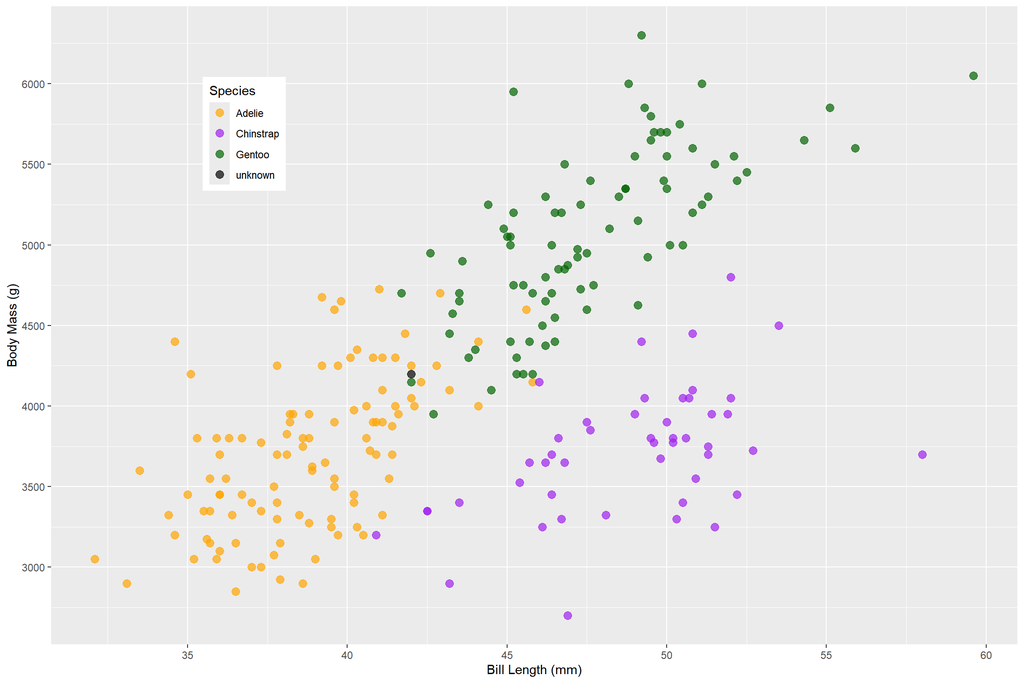

BodyMass and BillLength Related to penguin Species

## Eye Balling Techniques to Identify Penguin Species

#### Horizonal Boundary

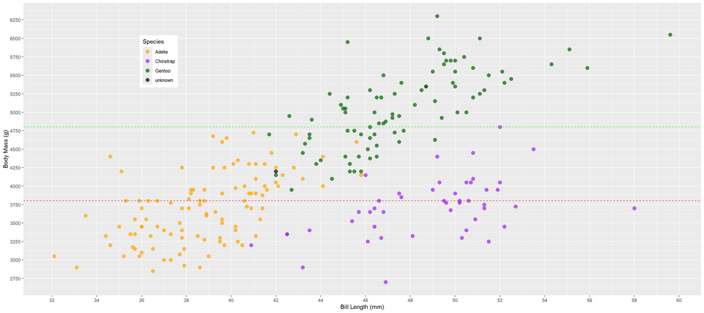

Horizontal Decision Boundary for Bill Length and Body Mass Related to Penguin Species

```r
ggplot(DataTrain |>
         add_row(Species="unknown", BillLengthMm=42, BodyMassG=4200),
       aes(y=BodyMassG, x=BillLengthMm, color=Species)) +
  labs(x="Bill Length (mm)", y="Body Mass (g)", color="Species",
       alt="A point plot of penguin bill length and body mass by species") +
  geom_point(size=3, alpha=0.7) +
  #geom_point(aes(x=42, y=4200), size=5, color="black") +
  scale_x_continuous(breaks=seq(30, 60, 2)) +
  scale_y_continuous(breaks=seq(2500, 6500, 250)) +
  scale_colour_manual(values = c("orange", "purple", "darkgreen", "black")) +
  geom_hline(yintercept = 3800, linetype = "dashed", color = "red") +
  geom_hline(yintercept = 4800, linetype = "dashed", color = "green") +
  theme(legend.position = c(0.2, 0.8))
```

#### Confusion Matrix

```
           Truth
Prediction  Adelie Chinstrap Gentoo
  Adelie    64     41        0
  Chinstrap 31     16        0
  Gentoo    0      30        56
```

#### Accuracy:

```
Overall Accuracy: 57.1 %
```

Can we improve the accuracy?

## Eyeballing Techniques to Identify Penguin Species

#### Creating Subspaces Like Similar to a Decision Tree

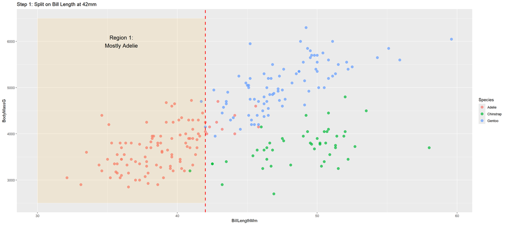

Sub-Space Boundaries for Bill Length

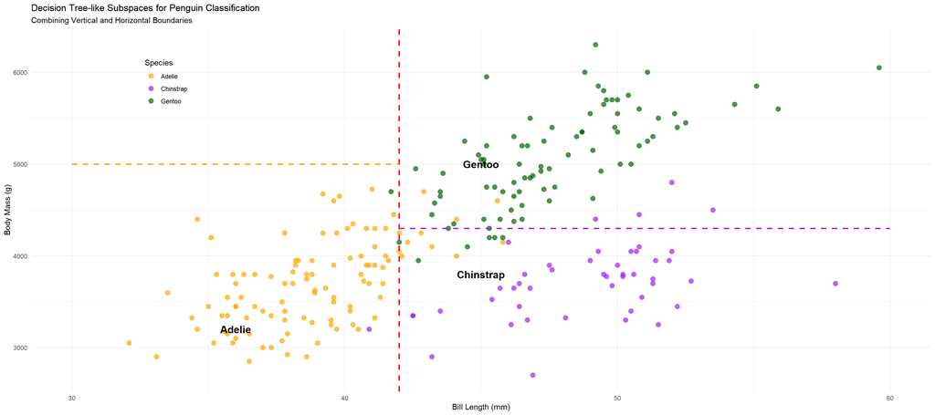

Sub-Space Boundaries for Bill Length

#### Confusion Matrix

```
           Predicted
Actual      Adelie Chinstrap Gentoo
  Adelie        96         6      3
  Chinstrap      1        42      4
  Gentoo         2         5     79
```

```
Tree-like Boundaries Accuracy: 91.2 %
```

## Eyeballing Techniques to Identify Penguin Species

#### Using a non-linear Decision Boundary Like a Neural Network

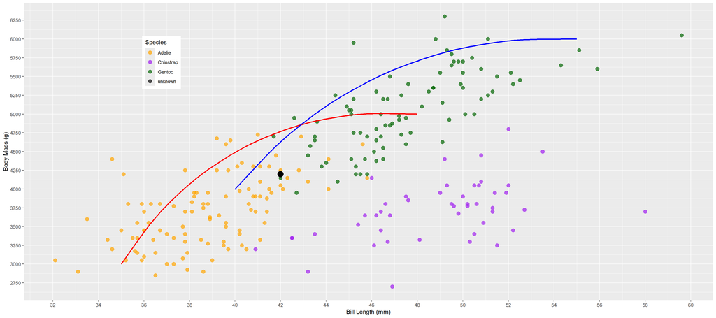

Multiple Curved Decision Boundaries for Penguin Species

### Confusion Matrix

```
           Truth
Prediction  Adelie Chinstrap Gentoo
  Adelie    13     68        24
  Chinstrap 32     14        1
  Gentoo    0      5         81
```

```
Non-linear Boundary Accuracy: 45.4 %
```

## So, how does k Nearest Neighbors Work?

- Predicts the class (species) for a new observation (penguin with unkown Species) by finding the observation closest to it - the nearest neighbor
- If k-Nearest Neighbors considers more than one neighboring point (k > 1 ), e.g., the four nearest neighbors (k = 4), the class of the majority of these neighbor points is the predicted class. In case of a tie, the prediction is chosen randomly
- the hyper-parameter k determines the number of neighbors to be considered.
  - k is called a hyper-parameter because it has to be chosen at the design stage of the model.
  - In contrast to parameters that are determined based on data

## k Nearest Neighbors k=1

- Most basic K-Nearest Neighbors model (k=1)

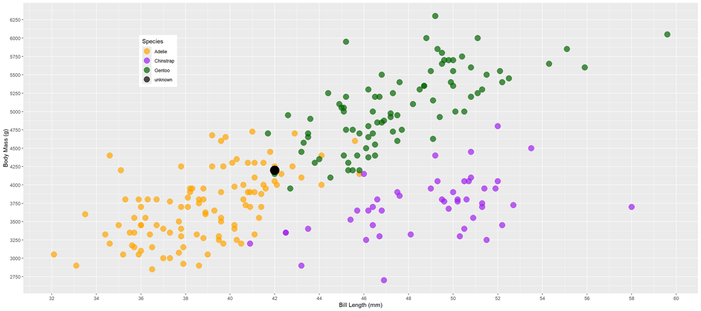

Bill Length and Body Mass Related to Penguin Species

## k Nearest Neighbors k=1

```
[1] "Nearest neighbor at: 42.3 4150"
```

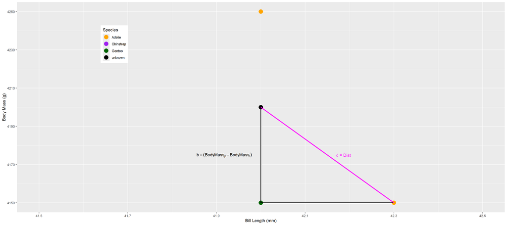

Predicting Penguin Species with k-Nearest Neighbors (k=1)

## How to calculate Euclidean Distance for Two Variables

Assume our observations have **two predictor variables** $x$ and $y$. We compare the unknown point $p$ to one of the points from the training data (e,g., point $i$):
$$Dist_i=\sqrt{(x_p-x_i)^2+(y_p-y_i)^2}$$
??

## How to calculate Euclidean Distance for Three Variables

Assume our observations have **three predictor variables** $x$, $y$, and $z$. We compare the unknown point $p$ to one of the points from the training data (e,g., point $i$):
$$Dist_i=\sqrt{(x_p-x_i)^2+(y_p-y_i)^2+(z_p-z_i)^2}$$
??

## How to calculate Euclidean Distance for N Variables

Assume our observations have $N$ predictor variables $v_j$ with $j=1 ... N$. We compare the unknown point $p$ to one of the points from the training data (e,g., point $i$):
$$Dist_i=\sqrt{\sum_{j=1}^N(v_{p,j}-v_{i,j})^2}$$
??

## k Nearest Neighbors k=4 (for a different unknown species)

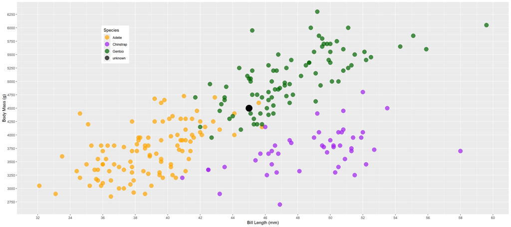

Bill Length and Body Mass Related to Penguin Species

## k Nearest Neighbors k=4 (for a different unknown species)

#### 4 nearest neighbors vote on species classification

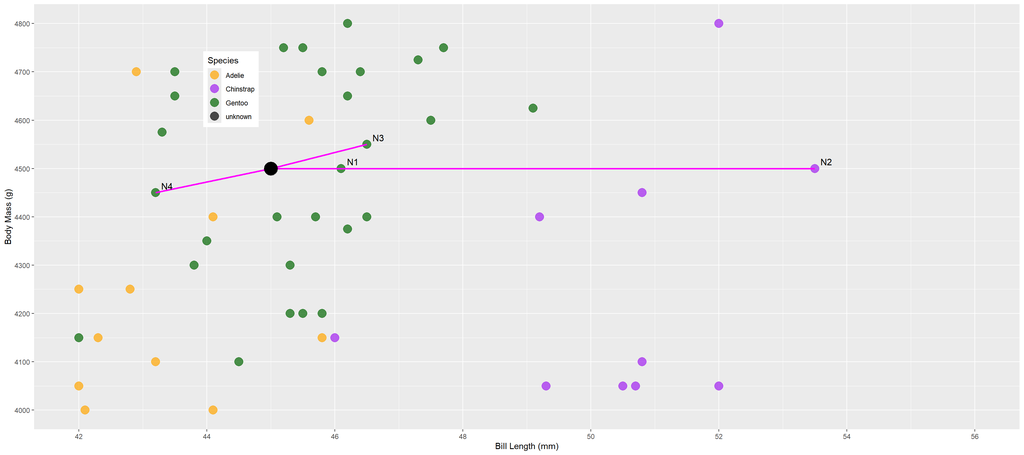

Predicting Penguin Species with k-Nearest Neighbors (k=4)

## Find the Optimal K hyperparameters

In a real-world application, you have to choose the value for the hyper-parameter  
k in the model design stage. The chosen  
k is then valid for all model predictions.  
This raises the question: **How do we find an appropriate value for k ?**

The answer is: We use a systematic trial-and-error process called ???tuning???.

Tuning to be covered in later chapters.

- Right now, you might be tempted to run the model for different values of k and then use the testing dataset to see which k delivers the best prediction performance.
  - This is not an appropriate way to optimize hyper-parameters. Using the testing dataset to optimize hyper-parameters can lead to overfitting
- Overfitting occurs when a prediction model performs well on the training data, but when it is used for preditions based on new data that the model has ???never seen before???, it performs poorly.
- In general, a k that is too low is prone to be influenced by isolated outliers, although the surrounding neighborhood would suggest otherwise.
- On the other hand, a k that is too high would consider a neighborhood so large that it does not represent the neighborhood surrounding the prediction point anymore

## k Nearest Neighbors k=4 (for a different unknown species)

#### Watch the scale: mm vs. g. Need better scaling!

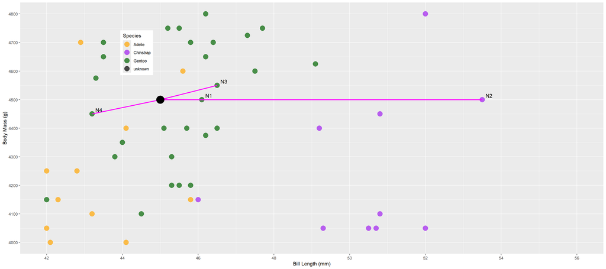

Bill Length and Body Mass Related to Penguin Species

## The Visual vs. The Reality

**What We See:**

N2 (purple point) looks very far away horizontally.

N4 (green point) looks much closer overall.

Visually, N4 should be the closer neighbor.

**What The Math Says:**

```r
# Distance to N2 (approx at 53, 4500)
bill_diff_N2 <- 53 - 45    # = 8 mm
mass_diff_N2 <- 4500 - 4500  # = 0 g
sqrt(bill_diff_N2^2 + mass_diff_N2^2)  # ??? 8
```

```
[1] 8
```

```r
# Distance to N4 (approx at 43, 4450)
bill_diff_N4 <- 43 - 45    # = -2 mm
mass_diff_N4 <- 4450 - 4500  # = -50 g
sqrt(bill_diff_N4^2 + mass_diff_N4^2)  # ??? 50
```

```
[1] 50.03998
```

## Why Does This Happen?

## The Scaling Problem

**Different Measurement Scales:**

| Variable | Units | Typical Range | Example Difference |
| --- | --- | --- | --- |
| Bill Length | millimeters (mm) | 30-60 | 0.1 - 2 mm |
| Body Mass | grams (g) | 2500-6500 | 20 - 500 g |

**The Problem:**

- Body Mass values are naturally **100-1000?? larger** than Bill Length values
- When we square these differences for Euclidean distance, the gap becomes **10,000-1,000,000?? larger**
- Body Mass **completely dominates** the distance calculation

**This is unfair!** Both measurements should contribute appropriately to finding the nearest neighbor.

## We Need to Scale Our Variables

**Goal:** Transform both variables to comparable ranges so neither dominates the distance calculation.

**Before Scaling:**

```
Bill Length:  42.1 - 42.0 = 0.1    ??? contributes 0.01 to distance??
```

```
Body Mass:   4220 - 4200 = 20      ??? contributes 400 to distance??
```

```
Body Mass dominates (99.997% of total distance)
```

## A Few Common Scaling Options

- **Same units**

  Divide or multiply to get the same units. This is often not possible (e.g., `BillLength` and `BodyMass`). Or it is not feasible (e.g. `BillLength` in mm and `BodyMass` in grams are in vastly different ranges)
- **Rescaling**

  Generates a variable $y$ that is scaled to a range between 0 and 1 based on the original variable’s value $x$, its minimum $x_{min}$ and its maximum $x_{max}$:
  $$y= \frac{x-x_{min}}{x_{max} - x_{min}}$$
- **Z-Score Normalization**

  Z-score normalization uses the mean ($\overline x$) and the standard deviation ($s$) of a variable to scale the variable $x$ to the variable $z$:

  $$z=\frac{x-\overline x}{s}$$
  ??

## Comparison: Before and After Scaling

**Raw Values (Problem)**

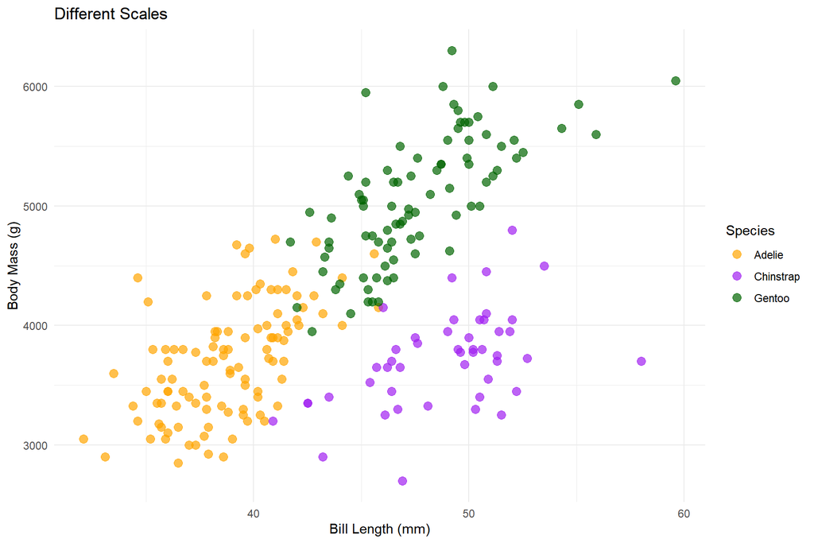

**Standardized Values (Solution)**

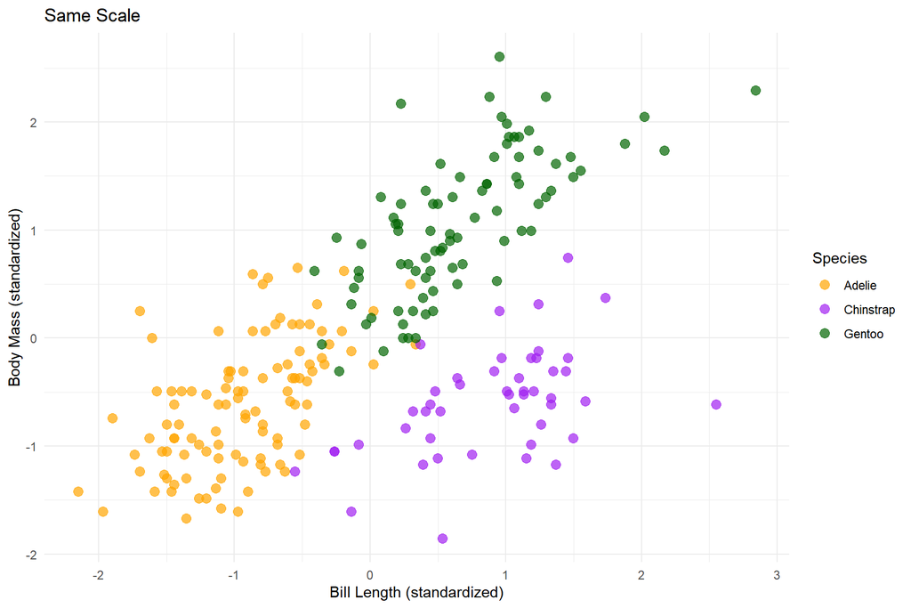

## Time to Run k-Nearest Neighbors

#### Loading Data and Selecting Variables

```r
library(tidyverse); library(janitor); library(palmerpenguins)
DataPenguins <- penguins %>%
         clean_names("upper_camel") %>%
         select(Species, BillLengthMm, BodyMassG) %>%
         drop_na() %>%
         mutate(Species = as.factor(Species))
print(DataPenguins[1:10,])  # Shows first 10 rows
```

```
# A tibble: 10 × 3
   Species BillLengthMm BodyMassG
   <fct>          <dbl>     <int>
 1 Adelie          39.1      3750
 2 Adelie          39.5      3800
 3 Adelie          40.3      3250
 4 Adelie          36.7      3450
 5 Adelie          39.3      3650
 6 Adelie          38.9      3625
 7 Adelie          39.2      4675
 8 Adelie          34.1      3475
 9 Adelie          42        4250
10 Adelie          37.8      3300
```

## Time to Run k-Nearest Neighbors

The `tidymodels` package provides a **standardized workflow** with standardized commands for the following tasks:

- Data splitting (training and testing)
- Pre-processing data with `recipes`
- Creating machine learning model-design with only three standardized commands
- Tuning hyper-parameters
- assessing prediciton quality using a set of predefined metrics

Generate Training and Testing Data (Splitting):

```r
library(tidymodels)
set.seed(876)
Split7030 = initial_split(DataPenguins, prop=0.7, strata = Species)
DataTrain = training(Split7030)
DataTest = testing(Split7030)
head(DataTrain)
```

```
# A tibble: 6 × 3
  Species BillLengthMm BodyMassG
  <fct>          <dbl>     <int>
1 Adelie          40.3      3250
2 Adelie          36.7      3450
3 Adelie          39.3      3650
4 Adelie          38.9      3625
5 Adelie          39.2      4675
6 Adelie          42        4250
```

```r
head(DataTest)
```

```
# A tibble: 6 × 3
  Species BillLengthMm BodyMassG
  <fct>          <dbl>     <int>
1 Adelie          39.1      3750
2 Adelie          39.5      3800
3 Adelie          34.1      3475
4 Adelie          41.1      3200
5 Adelie          36.6      3700
6 Adelie          38.7      3450
```

## Time to Run k-Nearest Neighbors

### [Click here to find a reference list for various `Step_` commands](https://recipes.tidymodels.org/reference/index.html)

- Recipes simplify data pre-processing
- You can compare a `tidymodels` recipe to a recipe in a cookbook.
  - First, the ingredients are listed, and then you find the steps to use these ingredients to cook the meal.

Recipe: Prepare Data for Analysis:

```r
DataTrain <- DataTrain %>% select(Species, BillLengthMm, BodyMassG)
RecipePenguins = recipe(Species ~ BillLengthMm + BodyMassG, data = DataTrain) |>
  step_naomit() |>
  step_normalize(all_predictors())
```

The recipe() command is followed by instructions on how to process the data step by step. Each step starts with step_, indicating that the instruction (command) is part of a recipe.

Or:

```r
RecipePenguins = recipe(Species~., data = DataTrain) |>
  step_naomit() |>
  step_normalize(all_predictors())
```

```r
print(RecipePenguins)
```

## Time to Run k-Nearest Neighbors

### [Click here to find a reference list for various ML algorithm commands](https://parsnip.tidymodels.org/reference/index.html)

a model-design determines which machine learning model from which R package should be used.

To define a model design within the `tidymodels` environment, only three commands (connected with |>) are required.

Creating a Model Design:

```r
ModelDesignKNN = nearest_neighbor(neighbors = 4, weight_func = "rectangular") |>
  set_engine("kknn") %>% #provides the name of the package that performs the ML algorithm
  set_mode("classification") #indicates if we perform classification or regression
print(ModelDesignKNN)
```

```
K-Nearest Neighbor Model Specification (classification)

Main Arguments:
  neighbors = 4
  weight_func = rectangular

Computational engine: kknn
```

## Time to Run k-Nearest Neighbors

So far, we’ve defined a `recipe` and a `model-design`

We put it all together in a `workflow`

Then, the workflow is fiited (calibrated) to the training data

Putting it all together in a **fitted** `workflow`:

```r
WFModelPenguins = workflow() |>
  add_recipe(RecipePenguins) |>
  add_model(ModelDesignKNN) |>
  fit(DataTrain)

print(WFModelPenguins)
```

```
══ Workflow [trained] ══════════════════════════════════════════════════════════
Preprocessor: Recipe
Model: nearest_neighbor()

── Preprocessor ────────────────────────────────────────────────────────────────
2 Recipe Steps

• step_naomit()
• step_normalize()

── Model ───────────────────────────────────────────────────────────────────────

Call:
kknn::train.kknn(formula = ..y ~ ., data = data, ks = min_rows(4,     data, 5), kernel = ~"rectangular")

Type of response variable: nominal
Minimal misclassification: 0.05882353
Best kernel: rectangular
Best k: 4
```

## Time to Run k-Nearest Neighbors

How to use the **fitted** `workflow` to predict the penguin species for the penguins in the testing dataset:

1. Start with observation $i=1$ from `DataTest` (the first observation).
2. Take observation $i$ from `DataTest` and use `BillLength` and `BodyMassG` to calculate the Euclidean distance to **each** of the observations of `DataTrain`.
3. Isolate the 4 observations with the smallest Euclidean distance and use the majority of their species as a prediction for observation $i$ from `DataTest` (in case of a tie, decide randomly).
4. Increase $i$ by one (i.e., take the next observation from `DataTest`) and go to step 2 (until all `DataTest` observations are processed).

## Time to Run k-Nearest Neighbors

Predicting with the fitted workflow using `predict()` (not exactly helpful!):

```r
DataPred = predict(WFModelPenguins, DataTest)
head(DataPred)
```

```
# A tibble: 6 × 1
  .pred_class
  <fct>
1 Adelie
2 Adelie
3 Adelie
4 Adelie
5 Adelie
6 Adelie
```

Note: we cannot see if the predicitons are correct because we cannot easily compare

## Time to Run k-Nearest Neighbors

Predicting with the fitted workflow using `augment()` which *augments* `DataTest` with the predictions:

```r
DataPredWithTestData=augment(WFModelPenguins, DataTest)
head(DataPredWithTestData)
```

```
# A tibble: 6 × 7
  .pred_class .pred_Adelie .pred_Chinstrap .pred_Gentoo Species BillLengthMm
  <fct>              <dbl>           <dbl>        <dbl> <fct>          <dbl>
1 Adelie              1               0               0 Adelie          39.1
2 Adelie              1               0               0 Adelie          39.5
3 Adelie              1               0               0 Adelie          34.1
4 Adelie              0.75            0.25            0 Adelie          41.1
5 Adelie              1               0               0 Adelie          36.6
6 Adelie              1               0               0 Adelie          38.7
# ℹ 1 more variable: BodyMassG <int>
```

## Having a Data Frame with `truth` and `estimate` we can calculate **performance metrics**

The `tidymodels` package provides several commands to calculate metrics that reflect predictive performance.

Most of these commands compare the `estimate` with the `truth` and then calculate the related metrics.

Confusion Matrix:

```r
ConfMatrixPenguins=conf_mat(DataPredWithTestData, truth = Species, estimate = .pred_class)
print(ConfMatrixPenguins)
```

```
           Truth
Prediction  Adelie Chinstrap Gentoo
  Adelie        42         2      1
  Chinstrap      1        19      0
  Gentoo         3         0     36
```

## Reading the Confusion Matrix

```
                Truth
Prediction  Adelie Chinstrap Gentoo
  Adelie      42       2        1
  Chinstrap    1      19        0
  Gentoo       3       0       36
```

- **Key Insight:** Calculate TP, FP, FN, TN *for each class separately*
- Think **“One-vs-Rest”** for each class

## Understanding the Metrics

**TP**: Correctly predicted as THIS class

**FP**: Incorrectly predicted as THIS class

**FN**: Actually WAS this class, but we predicted it as something else

**TN**: Correctly identified as NOT this class

## Understanding the Metrics

To make sure the accuracy rate is not misleading, we look at `accuracy()`, `sensitivity()`, `precision()` and `specificity()` for the penguin data.

- Sensitivity: the rate of correctly predicted positives
  - “Of all the actual positives, how many did we catch?”
- Precision: the rate of correct positive predicitons
  - “Of all our positive predictions, how many were correct?”
- Specificity: the rate of correctly predicted negatives
  - “Of all the actual negatives, how many did we correctly”

**Note**: In our case (3 classes), sensitivity and specificity need to be calculated for each class

**For each penguin species**, calculate separately

## Example: Adelie Penguins

*“Is this penguin an Adelie?”*

```
                Truth
Prediction  Adelie Chinstrap Gentoo
  Adelie     TP:42   FP: 2   FP: 1
  Chinstrap  FN: 1   TN:19   TN: 0
  Gentoo     FN: 3   TN: 0   TN:36
```

- TP = 42: Correctly identified as Adelie
- FP = 3: Said “Adelie” but wrong (2+1)
- FN = 4: Missed Adelie penguins (1+3)
- TN = 55: Correctly NOT Adelie (19+0+0+36)

**Precision** = TP/(TP+FP) = 42/(42+3) = 42/45 = **93.3%**

**Recall (Sensitivity)** = TP/(TP+FN) = 42/(42+4) = 42/46 = **91.3%**

**Specificity** = TN/(TN+FP) = 55/(55+3) = 55/58 = **94.8%**

## Example: Chinstrap Penguins

*“Is this penguin a Chinstrap?”*

```
                Truth
Prediction  Adelie Chinstrap Gentoo
  Adelie     TN:42   FN: 2   TN: 1
  Chinstrap  FP: 1   TP:19   FP: 0
  Gentoo     TN: 3   FN: 0   TN:36
```

- TP = 19: Correctly identified as Chinstrap
- FP = 1: Said “Chinstrap” but wrong (1+0)
- FN = 2: Missed Chinstrap penguins (2+0)
- TN = 82: Correctly NOT Chinstrap (42+1+3+36)

**Precision** = TP/(TP+FP) = 19/(19+1) = 19/20 = **95.0%**

**Recall (Sensitivity)** = TP/(TP+FN) = 19/(19+2) = 19/21 = **90.5%**

**Specificity** = TN/(TN+FP) = 82/(82+1) = 82/83 = **98.8%**

## Example: Gentoo Penguins

*“Is this penguin a Gentoo?”*

```
                Truth
Prediction  Adelie Chinstrap Gentoo
  Adelie     TN:42   TN: 2   FN: 1
  Chinstrap  TN: 1   TN:19   FN: 0
  Gentoo     FP: 3   FP: 0   TP:36
```

- TP = 36: Correctly identified as Gentoo
- FP = 3: Said “Gentoo” but wrong (3+0)
- FN = 1: Missed Gentoo penguins (1+0)
- TN = 64: Correctly NOT Gentoo (42+2+1+19)

**Precision** = TP/(TP+FP) = 36/(36+3) = 36/39 = **92.3%**

**Recall (Sensitivity)** = TP/(TP+FN) = 36/(36+1) = 36/37 = **97.3%**

**Specificity** = TN/(TN+FP) = 64/(64+3) = 64/67 = **95.5%**

## Summary: All Three Classes

| Class | TP | FP | FN | TN | Precision | Recall |
| --- | --- | --- | --- | --- | --- | --- |
| **Adelie** | 42 | 3 | 4 | 55 | 93.3% | 91.3% |
| **Chinstrap** | 19 | 1 | 2 | 82 | 95.0% | 90.5% |
| **Gentoo** | 36 | 3 | 1 | 64 | 92.3% | 97.3% |

**Overall Accuracy:** (42+19+36)/104 = **93.3%**

## Let’s Look at Metrics in R

```
# A tibble: 1 × 3
  .metric  .estimator .estimate
  <chr>    <chr>          <dbl>
1 accuracy multiclass     0.933
```

```r
sensitivity(DataPredWithTestData, truth = Species, estimate = .pred_class)
```

```
# A tibble: 1 × 3
  .metric     .estimator .estimate
  <chr>       <chr>          <dbl>
1 sensitivity macro          0.930
```

```r
specificity(DataPredWithTestData, truth = Species, estimate = .pred_class)
```

```
# A tibble: 1 × 3
  .metric     .estimator .estimate
  <chr>       <chr>          <dbl>
1 specificity macro          0.964
```

```r
precision(DataPredWithTestData, truth = Species, estimate = .pred_class)
```

```
# A tibble: 1 × 3
  .metric   .estimator .estimate
  <chr>     <chr>          <dbl>
1 precision macro          0.935
```

Get all the metrics at Once

```r
metrics_summary <- metric_set(sensitivity, specificity, precision, recall)
metrics_summary(DataPredWithTestData, truth = Species, estimate = .pred_class)
```

```
# A tibble: 4 × 3
  .metric     .estimator .estimate
  <chr>       <chr>          <dbl>
1 sensitivity macro          0.930
2 specificity macro          0.964
3 precision   macro          0.935
4 recall      macro          0.930
```

## When to Use Each Metric: Examples

**Medical Diagnosis (Cancer Detection)**  
- Prioritize: **Recall (Sensitivity)**  
- Don’t miss any cancer cases  
- Missing a positive case (FN) is very costly

**Spam Email Filter**  
- Prioritize: **Precision**  
- Don’t mark important emails as spam  
- False positives (legitimate email marked as spam) are costly

**COVID-19 Screening Test**  
- Prioritize: **Specificity**  
- Correctly identify healthy people  
- False positives cause unnecessary quarantine and anxiety

**Balanced Dataset (Equal class sizes)**  
- Use: **Accuracy**  
- Simple and interpretable  
- All error types have similar costs

**Imbalanced Dataset (e.g., fraud detection: 99% normal, 1% fraud)**  
- Avoid: Accuracy (can get 99% by predicting “normal” every time!)  
- Use: **Precision, Recall, and F1-Score**

## The Precision-Recall Trade-off

**There’s often a trade-off:**  
- Increasing **Recall** (catch more positives) ??? often decreases **Precision** (more false alarms)  
- Increasing **Precision** (fewer false alarms) ??? often decreases **Recall** (miss some positives)

**F1-Score balances both:**

```
F1-Score = 2 ?? (Precision ?? Recall) / (Precision + Recall)
```

- Harmonic mean of Precision and Recall
- Good when you need a single metric that balances both

**Our Penguin Example:** - Adelie: F1 = 2 ?? (0.933 ?? 0.913) / (0.933 + 0.913) = **0.923**  
- Chinstrap: F1 = 2 ?? (0.905 ?? 0.950) / (0.905 + 0.950) = **0.927**  
- Gentoo: F1 = 2 ?? (0.973 ?? 0.923) / (0.973 + 0.923) = **0.947**

# Project: Design a Machine Learning Workflow for Optical Character Recognition ??

## MNIST Data Set

You will develop a machine learning model based on k-Nearest Neighbors to recognize handwritten digits from images.

You will use the MNIST dataset, a standard dataset for image recognition in machine learning (60,000 images for training and 10,000 images for testing). Developed by LeCun, Cortes, and Burges (2010) based on two datasets from handwritten digits obtained from Census workers and high school students.

We will use only the first 500 images of the original MNIST dataset to speed up the *k-Nearest Neighbors* model’s training time.

## Visualization of the First Six Images from the MNIST Data Set

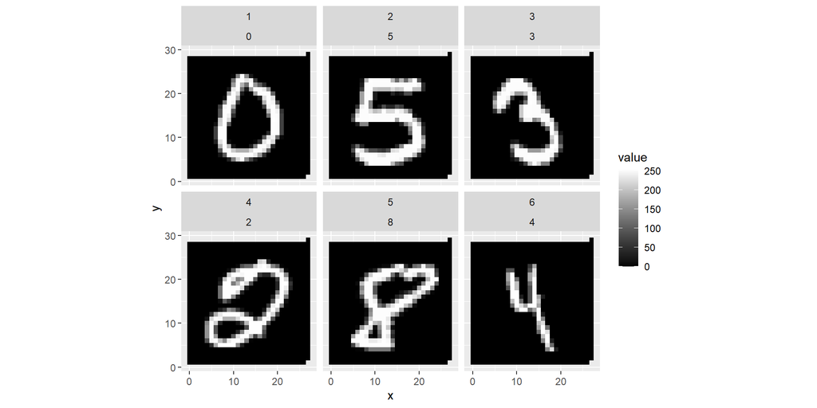

## How a Image is Stored in the Mnist Dataset

[figure not shown]

Image of a Handwritten Nine

The image has 28 rows and 28 columns. Each of the 784 cells (pixels) holds a value between 0 (black) and 255 (white)

## How a Image is Stored in the Mnist Dataset

[figure not shown]

Image of a Handwritten Nine

- Pixel values for a single image are not stored in a table. Ohterwise we would end-up with a table containing tables.
- Pixel values are stored as one row for each image.
- Concatenating the 28 rows of an image into one row with 28*28=784 cells (pixels)

## Three Rows from the Data Frame of the MNIST Dataset

```r
print(Mnist4PlotAndTable[1:3,1:784])
```

```
  Label Pix1 Pix2 Pix3 Pix4 Pix5 Pix6 Pix7 Pix8 Pix9 Pix10 Pix11 Pix12 Pix13
1     0    0    0    0    0    0    0    0    0    0     0     0     0     0
2     5    0    0    0    0    0    0    0    0    0     0     0     0     0
3     3    0    0    0    0    0    0    0    0    0     0     0     0     0
  Pix14 Pix15 Pix16 Pix17 Pix18 Pix19 Pix20 Pix21 Pix22 Pix23 Pix24 Pix25 Pix26
1     0     0     0     0     0     0     0     0     0     0     0     0     0
2     0     0     0     0     0     0     0     0     0     0     0     0     0
3     0     0     0     0     0     0     0     0     0     0     0     0     0
  Pix27 Pix28 Pix29 Pix30 Pix31 Pix32 Pix33 Pix34 Pix35 Pix36 Pix37 Pix38 Pix39
1     0     0     0     0     0     0     0     0     0     0     0     0     0
2     0     0     0     0     0     0     0     0     0     0     0     0     0
3     0     0     0     0     0     0     0     0     0     0     0     0     0
  Pix40 Pix41 Pix42 Pix43 Pix44 Pix45 Pix46 Pix47 Pix48 Pix49 Pix50 Pix51 Pix52
1     0     0     0     0     0     0     0     0     0     0     0     0     0
2     0     0     0     0     0     0     0     0     0     0     0     0     0
```

[output cut: 265 more lines]

## Go to Project in Book

### Build your own OCR system.??

See: [RandRStudioScriptPart1.R script300](https://ai.lange-analytics.com/exc/?file=04-KNearNeighExerc300.Rmd)